# IE 582 - HW 1 - Stock Exchange Data

## Google Trends

We want to check the news related with AKBNK, GARAN, SISE, and TRKCM (the stocks that we investigate in correlation analysis).

- Search URL: https://trends.google.com/trends/explore?date=2012-09-17%202019-07-23&geo=TR&gprop=news&q=%2Fg%2F12fzdqdn9,%2Fg%2F12fzdqc6p,%2Fg%2F12fzdq9mr,%2Fm%2F0cp7qbj
- You can see a few rows in the table below.
- We selected news trends instead of web search trends.
- For the date-range we choose, only monthly data is available. Thus, we conduct our analysis with monthly price data.

```python
trends_data_raw.head()
```

|  | Month | IST:AKBNK: (Türkiye) | IST:GARAN: (Türkiye) | IST:SISE: (Türkiye) | Trakya Cam Sanayii A.Ş.: (Türkiye) |
| --- | --- | --- | --- | --- | --- |
| 0 | 2012-10 | 0 | 0 | 0 | 0 |
| 1 | 2012-11 | 0 | 0 | 0 | 0 |
| 2 | 2012-12 | 0 | 0 | 25 | 0 |
| 3 | 2013-01 | 0 | 0 | 0 | 0 |
| 4 | 2013-02 | 0 | 0 | 0 | 0 |

```python
trends_data = trends_data_raw.copy()
trends_data.columns = ["year_month","AKBNK_news","GARAN_news","SISE_news","TRKCM_news"]
```

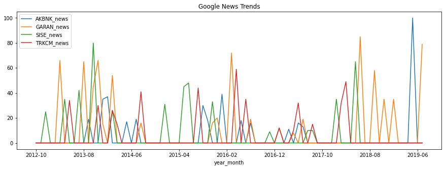

```python
trends_data.set_index("year_month").plot(title="Google News Trends",figsize=(15,5))
plt.show()
```

We checked the correlations between stoks and their related news.

- Interestingly, there seems no significant correlation between news and prices.
- The reason might be the high number of zero values in news data.
- Thus, looking point by point for the news events might be better.

```python
price_news_combined = pd.merge(
    data_monthly[["year_month","AKBNK","GARAN","SISE","TRKCM"]],
    trends_data,
    "outer"
)

news_correlations = price_news_combined.corr().stack().reset_index()
news_correlations.columns = ["ticker","news","corr"]
important_pairs = pd.DataFrame(np.array([
    ["AKBNK","AKBNK_news"],
    ["AKBNK","GARAN_news"],
    ["GARAN","AKBNK_news"],
    ["GARAN","GARAN_news"],
    ["SISE","SISE_news"],
    ["SISE","TRKCM_news"],
    ["TRKCM","SISE_news"],
    ["TRKCM","TRKCM_news"],
]),columns = ["ticker","news"])

important_pairs.merge(news_correlations,"left")
```

|  | ticker | news | corr |
| --- | --- | --- | --- |
| 0 | AKBNK | AKBNK_news | -0.223762 |
| 1 | AKBNK | GARAN_news | -0.168197 |
| 2 | GARAN | AKBNK_news | -0.200840 |
| 3 | GARAN | GARAN_news | -0.147852 |
| 4 | SISE | SISE_news | -0.141797 |
| 5 | SISE | TRKCM_news | -0.035312 |
| 6 | TRKCM | SISE_news | -0.065124 |
| 7 | TRKCM | TRKCM_news | -0.008905 |

Plots of news and prices are shown below.

- There seems like a negative relationship between banking news and stock prices. The news might include some negative contents.
- There is no apparent relation between glass industry stocks and their news trends.
- Monthly data might be too wide to see the effect of the news. One can examine the news one by one and observe the price changes around the arrival time to see a more detailed analysis.

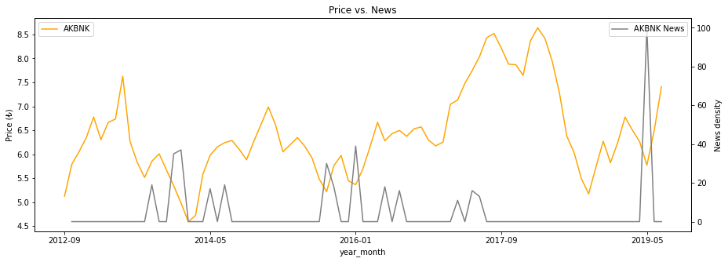

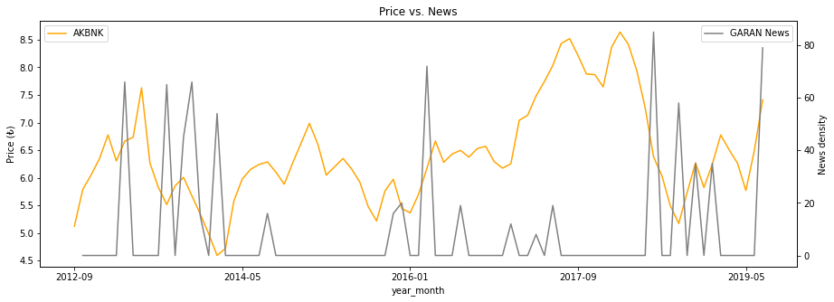

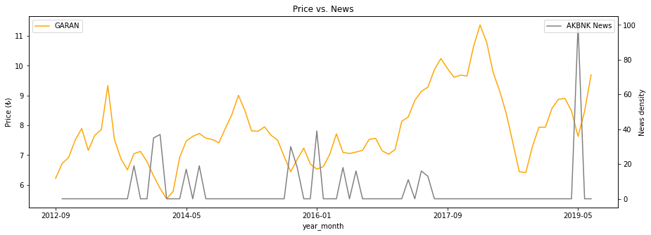

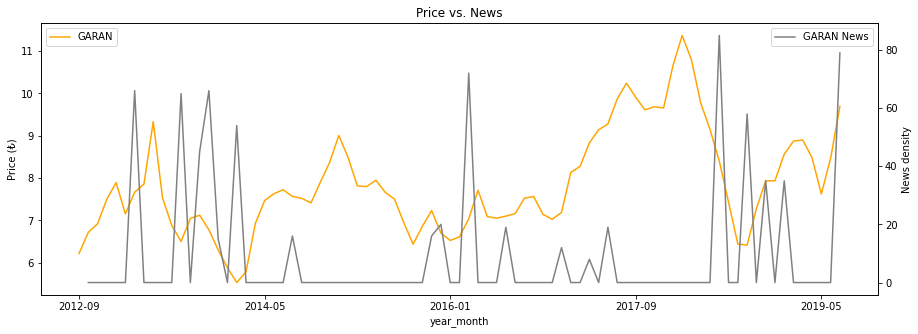

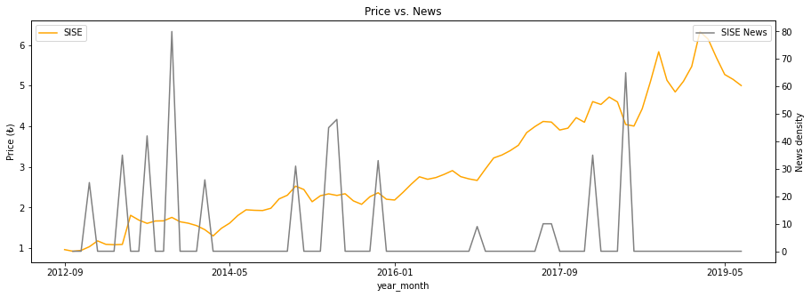

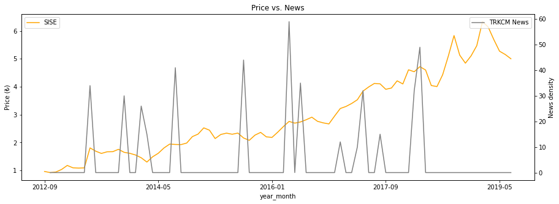

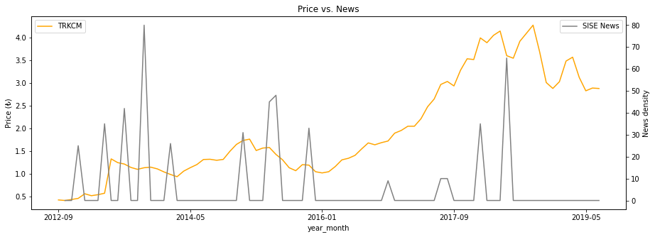

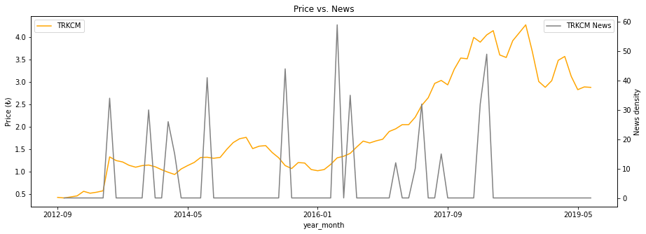

```python
for ticker,news in important_pairs.values:
    news = news.split("_")[0]
    fig, ax1 = plt.subplots(figsize=(15,5))
    ax2 = ax1.twinx()

    price_news_combined.set_index("year_month")[[ticker]].plot(ax=ax1,legend=False,color="orange")
    price_news_combined.set_index("year_month")[[news+"_news"]].plot(ax=ax2,color="gray",legend=False)
    ax1.legend([ticker],loc=2)
    ax2.legend([news+" News"],loc=1)
    ax1.set_ylabel("Price (₺)")
    ax2.set_ylabel("News density")
    plt.title("Price vs. News")
    plt.show()
```